# juliaent_7

```r
library("dplyr")
data("airquality")
airquality = airquality %>%
  subset(is.na(Solar.R)==FALSE & is.na(Ozone)==FALSE)
```

## Exercise 1

Manipulate the above code to reduce the correlation between X1 and X2 and recalculate the regression coefficients. Explain what you find.

hint: Increase the random noise of X1 and X2 so that the two can be less correlated.

```r
Y = seq(from=0, to=20, by=0.1)
X1 = (Y-2)/3 + runif(length(Y), min=0.1, max=10)
X2 = (Y+3)/2 + runif(length(Y), min=0.1, max=10)
df = as.data.frame(cbind(Y, X1, X2))
summary(lm(Y~X1, data=df))
```

```
##
## Call:
## lm(formula = Y ~ X1, data = df)
##
## Residuals:
##      Min       1Q   Median       3Q      Max
## -10.0431  -3.0745   0.3449   3.1358  11.6401
##
## Coefficients:
##             Estimate Std. Error t value Pr(>|t|)
## (Intercept)  1.91900    0.78954   2.431    0.016 *
## X1           1.00904    0.09001  11.210   <2e-16 ***
## ---
## Signif. codes:  0 '***' 0.001 '**' 0.01 '*' 0.05 '.' 0.1 ' ' 1
##
## Residual standard error: 4.565 on 199 degrees of freedom
## Multiple R-squared:  0.3871, Adjusted R-squared:  0.384
## F-statistic: 125.7 on 1 and 199 DF,  p-value: < 2.2e-16
```

```r
summary(lm(Y~X2, data=df))
```

```
##
## Call:
## lm(formula = Y ~ X2, data = df)
##
## Residuals:
##     Min      1Q  Median      3Q     Max
## -8.1085 -3.0208  0.0056  3.0148  9.0190
##
## Coefficients:
##             Estimate Std. Error t value Pr(>|t|)
## (Intercept) -1.50178    0.82283  -1.825   0.0695 .
## X2           0.98819    0.06638  14.886   <2e-16 ***
## ---
## Signif. codes:  0 '***' 0.001 '**' 0.01 '*' 0.05 '.' 0.1 ' ' 1
##
## Residual standard error: 4.011 on 199 degrees of freedom
## Multiple R-squared:  0.5269, Adjusted R-squared:  0.5245
## F-statistic: 221.6 on 1 and 199 DF,  p-value: < 2.2e-16
```

```r
summary(lm(Y~X1+X2, data=df))
```

```
##
## Call:
## lm(formula = Y ~ X1 + X2, data = df)
##
## Residuals:
##     Min      1Q  Median      3Q     Max
## -8.8141 -2.3809 -0.0546  2.4953  8.2434
##
## Coefficients:
##             Estimate Std. Error t value Pr(>|t|)
## (Intercept) -3.69802    0.77525  -4.770 3.57e-06 ***
## X1           0.60328    0.07758   7.777 4.00e-13 ***
## X2           0.76178    0.06512  11.698  < 2e-16 ***
## ---
## Signif. codes:  0 '***' 0.001 '**' 0.01 '*' 0.05 '.' 0.1 ' ' 1
##
## Residual standard error: 3.52 on 198 degrees of freedom
## Multiple R-squared:  0.6376, Adjusted R-squared:  0.6339
## F-statistic: 174.1 on 2 and 198 DF,  p-value: < 2.2e-16
```

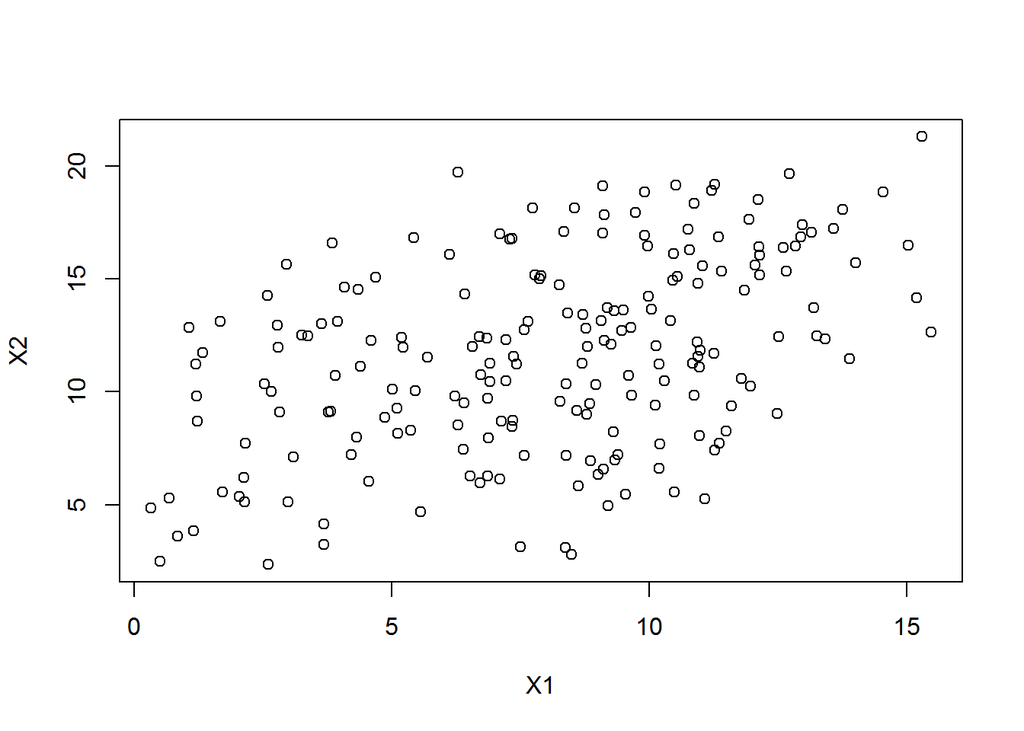

```r
plot(X1, X2)
```

```r
cor(X1, X2)
```

```
## [1] 0.4470974
```

## As the min decreases and max increases, X1 and X2 become less correlated, the plot becomes less linear and correlation coefficient gets smaller.

## Exercise 2

[Bonus, 2 pts] Challenge yourself by calculateing the RSS of the two models, F statistics (1 pt) and the p-value (1 pt) all by yourself (i.e. not using the anova() function)

Compare a third model (mod3) with ozone varaible as the third independent variable to mod1 and mod2 above. Does it explain more variance? Does it give you reasonable estimate of regressino coefficients? Important F-test can only be used to compare the ?ested?? models!

```r
mod1 = lm(Temp~Wind, data=airquality)
summary(mod1)
```

```
##
## Call:
## lm(formula = Temp ~ Wind, data = airquality)
##
## Residuals:
##     Min      1Q  Median      3Q     Max
## -19.112  -5.646   1.014   6.254  18.888
##
## Coefficients:
##             Estimate Std. Error t value Pr(>|t|)
## (Intercept)  91.0305     2.3489  38.754  < 2e-16 ***
## Wind         -1.3318     0.2226  -5.983 2.84e-08 ***
## ---
## Signif. codes:  0 '***' 0.001 '**' 0.01 '*' 0.05 '.' 0.1 ' ' 1
##
## Residual standard error: 8.306 on 109 degrees of freedom
## Multiple R-squared:  0.2472, Adjusted R-squared:  0.2403
## F-statistic: 35.79 on 1 and 109 DF,  p-value: 2.842e-08
```

```r
mod2 = lm(Temp~Wind+Solar.R, data=airquality)
summary(mod2)
```

```
##
## Call:
## lm(formula = Temp ~ Wind + Solar.R, data = airquality)
##
## Residuals:
##      Min       1Q   Median       3Q      Max
## -17.2714  -5.0237   0.5837   5.2545  18.4608
##
## Coefficients:
##              Estimate Std. Error t value Pr(>|t|)
## (Intercept) 85.702275   2.925445  29.295  < 2e-16 ***
## Wind        -1.251870   0.217207  -5.763 7.89e-08 ***
## Solar.R      0.024533   0.008478   2.894  0.00461 **
## ---
## Signif. codes:  0 '***' 0.001 '**' 0.01 '*' 0.05 '.' 0.1 ' ' 1
##
## Residual standard error: 8.039 on 108 degrees of freedom
## Multiple R-squared:  0.3014, Adjusted R-squared:  0.2884
## F-statistic: 23.29 on 2 and 108 DF,  p-value: 3.886e-09
```

```r
mod3 = lm(Temp~Wind+Solar.R+Ozone, data = airquality)
summary(mod3)
```

```
##
## Call:
## lm(formula = Temp ~ Wind + Solar.R + Ozone, data = airquality)
##
## Residuals:
##     Min      1Q  Median      3Q     Max
## -20.942  -4.996   1.283   4.434  13.168
##
## Coefficients:
##              Estimate Std. Error t value Pr(>|t|)
## (Intercept) 72.418579   3.215525  22.522  < 2e-16 ***
## Wind        -0.322945   0.233264  -1.384    0.169
## Solar.R      0.007276   0.007678   0.948    0.345
## Ozone        0.171966   0.026390   6.516 2.42e-09 ***
## ---
## Signif. codes:  0 '***' 0.001 '**' 0.01 '*' 0.05 '.' 0.1 ' ' 1
##
## Residual standard error: 6.834 on 107 degrees of freedom
## Multiple R-squared:  0.4999, Adjusted R-squared:  0.4858
## F-statistic: 35.65 on 3 and 107 DF,  p-value: 4.729e-16
```

```r
anova(mod1, mod2, mod3)
```

```
## Analysis of Variance Table
##
## Model 1: Temp ~ Wind
## Model 2: Temp ~ Wind + Solar.R
## Model 3: Temp ~ Wind + Solar.R + Ozone
##   Res.Df    RSS Df Sum of Sq      F    Pr(>F)
## 1    109 7520.7
## 2    108 6979.5  1    541.17 11.589 0.0009349 ***
## 3    107 4996.6  1   1982.90 42.463 2.424e-09 ***
## ---
## Signif. codes:  0 '***' 0.001 '**' 0.01 '*' 0.05 '.' 0.1 ' ' 1
```

## From the output table, we see that the RSS of mod3 is less than that of mod1 and mod2. The interpretation of these results is that mod3 explains a significantly greater amount of varaince compared to mod1 and mod2, because the probability for mod1 or mod 2 to explain the same amount of variance as mod3 is shown by the p values. The F statistic is 42.463.

## Exercise 3

Compare the AIC of the three models above mod1, mod2, and mod3. Do you have different conclusion in terms of which model performs better?

```r
AIC(mod1, mod2, mod3)
```

```
##      df      AIC
## mod1  3 788.9671
## mod2  4 782.6779
## mod3  5 747.5795
```

## Mod3 is the best preforming model because it has the smallest AIC value